# Latihan 2 - Pemodelan ARDL (Sales vs Advertising)

Putra Ramadhana

## Packages

```r
library(dLagM)
library(dynlm)
library(MLmetrics)
library(lmtest)
library(car)
```

## Latar Belakang

Soal meminta pemodelan **Autoregressive Distributed Lag (ARDL)** dari *Sales* (Y) terhadap *Advertising* (X) menggunakan data tahunan 1975-2014 (40 periode), lalu menentukan model terbaik. Pada model ARDL, $Y_t$ dipengaruhi oleh $X_t$, lag dari $X$, dan lag dari dirinya sendiri $Y_{t-1}$, dengan bentuk umum ARDL$(p,q)$:

$$Y_t = \alpha + \sum_{i=0}^{p}\beta_iX_{t-i} +
\sum_{j=1}^{q}\phi_jY_{t-j} + \varepsilon_t$$

## Impor Data

Data diinput persis sesuai tabel pada soal (40 tahun, 1975-2014).

```r
Year <- 1975:2014

Sales <- c(11.7,12.0,12.3,12.8,13.1,13.6,13.9,14.4,14.7,15.3,
           15.5,15.8,16.1,16.6,16.9,16.7,16.9,17.4,17.6,17.9,
           18.0,17.9,18.0,18.2,18.2,18.3,18.6,19.2,19.3,19.5,
           19.2,19.3,19.5,20.0,20.0,19.9,19.8,19.9,20.2,21.0)

Advertising <- c(9.4,9.6,10.0,10.4,10.8,10.9,11.7,12.2,12.5,12.9,
                  13.0,13.2,13.8,14.2,14.6,14.4,15.0,15.4,15.7,15.9,
                  15.9,16.0,16.3,16.2,16.8,17.3,17.6,18.1,18.3,18.5,
                  18.7,18.9,19.2,20.0,20.0,20.3,20.4,21.0,21.5,22.1)

data <- data.frame(Year = Year, Sales = Sales, Advertising = Advertising)
str(data)
```

```
## 'data.frame':    40 obs. of  3 variables:
##  $ Year       : int  1975 1976 1977 1978 1979 1980 1981 1982 1983 1984 ...
##  $ Sales      : num  11.7 12 12.3 12.8 13.1 13.6 13.9 14.4 14.7 15.3 ...
##  $ Advertising: num  9.4 9.6 10 10.4 10.8 10.9 11.7 12.2 12.5 12.9 ...
```

```r
data
```

```
##    Year Sales Advertising
## 1  1975  11.7         9.4
## 2  1976  12.0         9.6
## 3  1977  12.3        10.0
## 4  1978  12.8        10.4
## 5  1979  13.1        10.8
## 6  1980  13.6        10.9
## 7  1981  13.9        11.7
## 8  1982  14.4        12.2
## 9  1983  14.7        12.5
## 10 1984  15.3        12.9
## 11 1985  15.5        13.0
## 12 1986  15.8        13.2
## 13 1987  16.1        13.8
## 14 1988  16.6        14.2
```

[output cut: 26 more lines]

## Pembagian Data

Data dibagi menjadi data latih (30 tahun pertama: 1975-2004) dan data uji (10 tahun terakhir: 2005-2014)

```r
train <- data[1:30, ]
test  <- data[31:40, ]

train.ts <- ts(train)
test.ts  <- ts(test)
```

## Penentuan Orde ARDL Optimum

Pencarian orde $(p,q)$ dilakukan dengan `dLagM::ardlBoundOrders()`.

```r
order.search <- ardlBoundOrders(data = data.frame(train),
                                 formula = Sales ~ Advertising,
                                 ic = "AIC", max.p = 5, max.q = 5)
order.search$Stat.table
```

```
##            q = 1      q = 2      q = 3     q = 4      q = 5
## p = 1 -17.699638 -15.159785 -11.171253 -12.97933  -9.595366
## p = 2 -15.479841 -13.700376  -9.602500 -11.28856  -8.094541
## p = 3 -12.842321 -12.842321 -11.353394 -12.78397 -10.302797
## p = 4 -10.635346  -8.929704  -8.929704 -12.70373  -9.983369
## p = 5  -9.806117 -13.826706 -13.057325 -13.05733 -11.391142
```

Nilai AIC terkecil pada tabel di atas diperoleh pada $p=1$ dan $q=1$, sehingga ARDL$(1,1)$ menjadi kandidat orde yang paling efisien dan optimum berdasarkan AIC.

## Pemodelan ARDL

### ARDL(1,1) — kandidat terbaik

```r
model.ardl11 <- ardlDlm(formula = Sales ~ Advertising, data = train, p = 1, q = 1)
summary(model.ardl11)
```

```
##
## Time series regression with "ts" data:
## Start = 2, End = 30
##
## Call:
## dynlm(formula = as.formula(model.text), data = data)
##
## Residuals:
##       Min        1Q    Median        3Q       Max
## -0.229277 -0.127437  0.009143  0.109228  0.259132
##
## Coefficients:
##               Estimate Std. Error t value Pr(>|t|)
## (Intercept)    1.55786    0.44353   3.512  0.00171 **
## Advertising.t  0.29110    0.13707   2.124  0.04376 *
## Advertising.1 -0.09584    0.16067  -0.596  0.55621
## Sales.1        0.74360    0.09964   7.463 8.14e-08 ***
## ---
## Signif. codes:  0 '***' 0.001 '**' 0.01 '*' 0.05 '.' 0.1 ' ' 1
##
## Residual standard error: 0.1576 on 25 degrees of freedom
## Multiple R-squared:  0.9955, Adjusted R-squared:  0.9949
## F-statistic:  1830 on 3 and 25 DF,  p-value: < 2.2e-16
```

```r
AIC(model.ardl11); BIC(model.ardl11)
```

```
## [1] -19.18177
```

```
## [1] -12.34529
```

### Kandidat pembanding: ARDL(2,2), ARDL(3,1), ARDL(1,2)

```r
model.ardl22 <- ardlDlm(formula = Sales ~ Advertising, data = train, p = 2, q = 2)
model.ardl31 <- ardlDlm(formula = Sales ~ Advertising, data = train, p = 3, q = 1)
model.ardl12 <- ardlDlm(formula = Sales ~ Advertising, data = train, p = 1, q = 2)

data.frame(
  Model = c("ARDL(1,1)", "ARDL(2,2)", "ARDL(3,1)", "ARDL(1,2)"),
  AIC = c(AIC(model.ardl11), AIC(model.ardl22), AIC(model.ardl31), AIC(model.ardl12)),
  BIC = c(BIC(model.ardl11), BIC(model.ardl22), BIC(model.ardl31), BIC(model.ardl12))
)
```

```
## [1] -19.18177
## [1] -17.69964
## [1] -17.00034
## [1] -16.68436
## [1] -12.34529
## [1] -8.374206
## [1] -7.929482
## [1] -8.691135
```

```
##       Model       AIC        BIC
## 1 ARDL(1,1) -19.18177 -12.345286
## 2 ARDL(2,2) -17.69964  -8.374206
## 3 ARDL(3,1) -17.00034  -7.929482
## 4 ARDL(1,2) -16.68436  -8.691135
```

## Peramalan dan Akurasi Tiap Kandidat

```r
fore.ardl11 <- forecast(model = model.ardl11, x = test$Advertising, h = 10)
fore.ardl22 <- forecast(model = model.ardl22, x = test$Advertising, h = 10)
fore.ardl31 <- forecast(model = model.ardl31, x = test$Advertising, h = 10)
fore.ardl12 <- forecast(model = model.ardl12, x = test$Advertising, h = 10)

mape.ardl11 <- MAPE(fore.ardl11$forecasts, test$Sales)
mape.ardl22 <- MAPE(fore.ardl22$forecasts, test$Sales)
mape.ardl31 <- MAPE(fore.ardl31$forecasts, test$Sales)
mape.ardl12 <- MAPE(fore.ardl12$forecasts, test$Sales)

akurasi <- data.frame(
  Model = c("ARDL(1,1)", "ARDL(2,2)", "ARDL(3,1)", "ARDL(1,2)"),
  AIC   = c(AIC(model.ardl11), AIC(model.ardl22), AIC(model.ardl31), AIC(model.ardl12)),
  BIC   = c(BIC(model.ardl11), BIC(model.ardl22), BIC(model.ardl31), BIC(model.ardl12)),
  MAPE_test = c(mape.ardl11, mape.ardl22, mape.ardl31, mape.ardl12)
)
```

```
## [1] -19.18177
## [1] -17.69964
## [1] -17.00034
## [1] -16.68436
## [1] -12.34529
## [1] -8.374206
## [1] -7.929482
## [1] -8.691135
```

```r
akurasi
```

```
##       Model       AIC        BIC  MAPE_test
## 1 ARDL(1,1) -19.18177 -12.345286 0.04848320
## 2 ARDL(2,2) -17.69964  -8.374206 0.04247669
## 3 ARDL(3,1) -17.00034  -7.929482 0.04313037
## 4 ARDL(1,2) -16.68436  -8.691135 0.04806171
```

```r
GoF(model.ardl11)
```

```
##               n       MAE           MPE        MAPE       sMAPE      MASE
## model.ardl11 29 0.1238592 -0.0001484019 0.007696613 0.007697173 0.4281553
##                    MSE     MRAE     GMRAE
## model.ardl11 0.0214047 81884782 0.7548444
```

ARDL(2,2) sedikit unggul pada MAPE data uji, tetapi menggunakan parameter lebih banyak dan memiliki AIC serta BIC yang lebih besar (lebih buruk) dibandingkan ARDL(1,1). Karena selisih MAPE keduanya sangat kecil, **ARDL(1,1)** dipilih sebagai **model terbaik** karena lebih sederhana, memiliki AIC dan BIC terkecil, dan akurasi peramalannya tetap sangat baik.

## Model Terbaik: ARDL(1,1)

Model ARDL(1,1) yang terpilih adalah:

$$\hat{Sales}_t = 1.5579 + 0.2911\,Advertising_t -
0.0958\,Advertising_{t-1} + 0.7436\,Sales_{t-1}$$

Nilai $p$*-value* menunjukkan bahwa $Advertising_t$ ($p=0.044$) dan $Sales_{t-1}$ ($p<0.001$) berpengaruh signifikan terhadap $Sales_t$ pada taraf nyata 5%, sedangkan $Advertising_{t-1}$ tidak signifikan ($p=0.556$). Model ini memiliki $R^2_{adj} = 0.9949$, artinya hampir seluruh keragaman *Sales* mampu dijelaskan oleh model.

### Uji Diagnostik Model Terbaik

```r
cons_ardl <- dynlm(Sales ~ Advertising + L(Advertising) + L(Sales), data = train.ts)

cat("Uji Autokorelasi (Durbin-Watson):\n")
```

```
## Uji Autokorelasi (Durbin-Watson):
```

```r
dwtest(cons_ardl)
```

```
##
##  Durbin-Watson test
##
## data:  cons_ardl
## DW = 1.9917, p-value = 0.3507
## alternative hypothesis: true autocorrelation is greater than 0
```

```r
cat("Uji Heteroskedastisitas (Breusch-Pagan):\n")
```

```
## Uji Heteroskedastisitas (Breusch-Pagan):
```

```r
bptest(cons_ardl)
```

```
##
##  studentized Breusch-Pagan test
##
## data:  cons_ardl
## BP = 0.66214, df = 3, p-value = 0.8821
```

```r
cat("Uji Normalitas Residual (Shapiro-Wilk):\n")
```

```
## Uji Normalitas Residual (Shapiro-Wilk):
```

```r
shapiro.test(residuals(cons_ardl))
```

```
##
##  Shapiro-Wilk normality test
##
## data:  residuals(cons_ardl)
## W = 0.95502, p-value = 0.2466
```

- Uji Durbin-Watson: $p$*-value* = 0.351 (> 0.05) → **tidak ada autokorelasi**.
- Uji Breusch-Pagan: $p$*-value* = 0.882 (> 0.05) → **tidak ada heteroskedastisitas**
- Uji Shapiro-Wilk: $p$*-value* = 0.247 (> 0.05) → **residual berdistribusi normal**.

Ketiga asumsi (non-autokorelasi, homoskedastisitas, dan normalitas residual) terpenuhi, sehingga model ARDL(1,1) layak digunakan.

### Peramalan 10 Tahun ke Depan (Data Uji)

```r
fore.ardl11
```

```
## $forecasts
##  [1] 19.72862 19.93768 20.16129 20.53170 20.73047 20.96560 21.14081 21.43616
##  [9] 21.74384 22.09937
##
## $call
## forecast.ardlDlm(model = model.ardl11, x = test$Advertising,
##     h = 10)
##
## attr(,"class")
## [1] "forecast.ardlDlm" "dLagM"
```

```r
mape.ardl11
```

```
## [1] 0.0484832
```

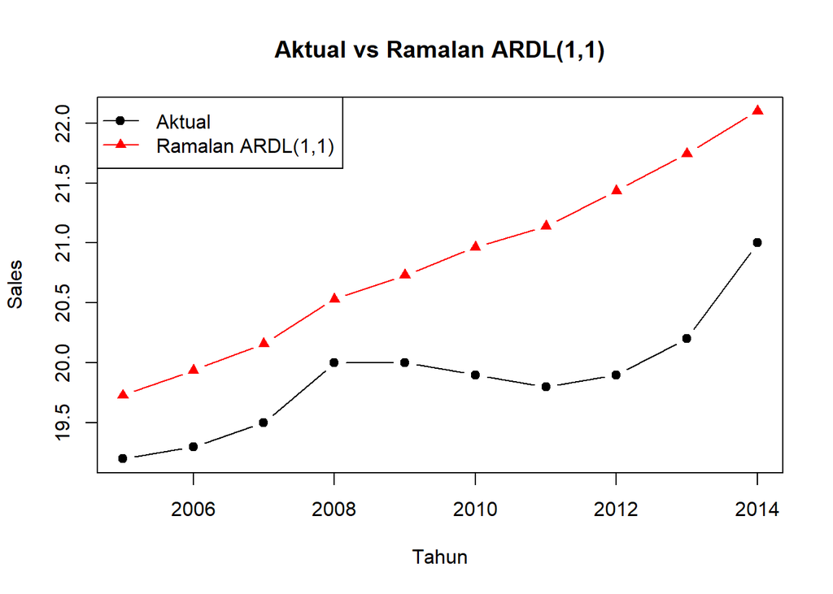

```r
plot(test$Year, test$Sales, type = "b", col = "black", pch = 19,
     xlab = "Tahun", ylab = "Sales", main = "Aktual vs Ramalan ARDL(1,1)",
     ylim = range(c(test$Sales, fore.ardl11$forecasts)))
lines(test$Year, fore.ardl11$forecasts, col = "red", type = "b", pch = 17)
legend("topleft", c("Aktual", "Ramalan ARDL(1,1)"), col = c("black", "red"),
       lty = 1, pch = c(19, 17))
```

## Kesimpulan

Model **ARDL(1,1)** merupakan model *distributed lag* terbaik untuk menjelaskan hubungan *Sales* terhadap *Advertising* pada data ini, karena:

1. Memiliki AIC dan BIC terkecil di antara kandidat orde yang diuji
2. Akurasi peramalan pada data uji sangat baik, dengan **MAPE ≈ 4.85%** (di bawah 10%, dikategorikan peramalan sangat akurat).
3. Lolos ketiga uji asumsi residual (non-autokorelasi, homoskedastisitas, dan normalitas).
4. Baik pengeluaran iklan periode berjalan ($Advertising_t$) maupun *Sales* periode sebelumnya ($Sales_{t-1}$) terbukti berpengaruh signifikan terhadap *Sales* saat ini, sejalan dengan intuisi bisnis bahwa efek iklan tidak sepenuhnya instan dan penjualan memiliki kelembaman (*persistence*) dari waktu ke waktu.